# Exercices Session V: Generalized linear models

Applied Biostatistics Course with R

Author

Biostatistics Support and Research Unit, IGTP

**Note**

The `regicor` dataset consists of data from 3 different cross-sectional surveys of individuals representative of the population from a north-west Spanish province (Girona), REGICOR study.

See `?regicor` for information on the variables in this dataset.

**1.** Read the data stored in the txt file `regicor.txt`. Save it as an object.

```r
regicor <- read.table("Data/regicor.txt", header=T)
```

**2.** Check the structure of the data.

1. How many variables and records does the data have?

```r
#Number of variables:
ncol(regicor)
```

```
[1] 25
```

```r
#Number of records:
nrow(regicor)
```

```
[1] 2148
```

2. Describe variables `chol`, `smoker` and `cv`. How many missings does `smoker` have?

```r
library(gtsummary)
regicor |>
  select(chol, smoker, cv)|>
  tbl_summary(label=list(chol ~ "Cholesterol", smoker ~ "Smoker", cv ~ "Cardiovascular event"))
```

| **Characteristic** | **N = 2,148**<sup>1</sup> |
| --- | --- |
| Cholesterol | 215 (189, 245) |
| Unknown | 76 |
| Smoker |  |
| Current or former < 1y | 557 (26%) |
| Former >= 1y | 415 (20%) |
| Never smoker | 1,138 (54%) |
| Unknown | 38 |
| Cardiovascular event | 89 (4.4%) |
| Unknown | 104 |

<sup>1</sup> Median (Q1, Q3); n (%)

**3.** Build a linear regression model to explain how the values of cholesterol (`chol`) vary according to the values of systolic blood pressure (`sbp`). Name it `m1`.

1. Which is the response/dependent variable?

chol

2. Which is the predictor/independent variable?

sbp

3. Visualize the relationship of the variables in a plot to see if it is linear.

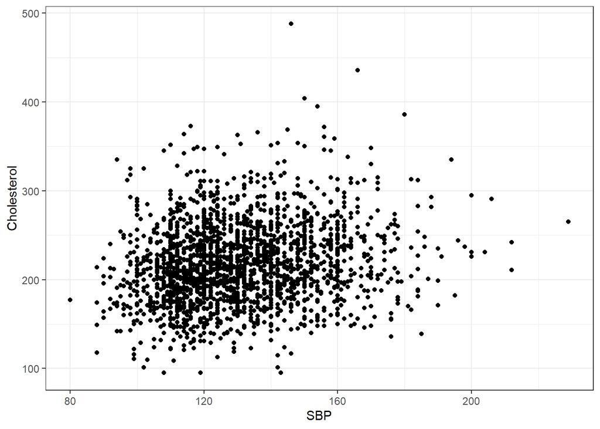

```r
library(ggplot2)
ggplot(regicor, aes(x=sbp, y=chol))+
geom_point() +
labs(x = "SBP", y = "Cholesterol")+
theme_bw()
```

4. Fit the model and interpret its coefficients.

```r
m1 <- lm(chol ~ sbp, data=regicor)
summary(m1)
```

```
Call:
lm(formula = chol ~ sbp, data = regicor)

Residuals:
     Min       1Q   Median       3Q      Max
-128.441  -29.774   -2.718   25.837  263.393

Coefficients:
             Estimate Std. Error t value Pr(>|t|)
(Intercept) 167.82816    6.34017  26.471  < 2e-16 ***
sbp           0.38890    0.04785   8.127 7.51e-16 ***
---
Signif. codes:  0 '***' 0.001 '**' 0.01 '*' 0.05 '.' 0.1 ' ' 1

Residual standard error: 44.4 on 2069 degrees of freedom
  (77 observations deleted due to missingness)
Multiple R-squared:  0.03093,   Adjusted R-squared:  0.03046
F-statistic: 66.04 on 1 and 2069 DF,  p-value: 7.507e-16
```

168 would be the predicted cholesterol value for an individual with sbp=0.

sbp has a statistically significant effect in cholesterol (p-value < 0.05).

An increase of 1 mmHg in sbp increases cholesterol in 0.39 mg/dl.

5. Build a table to visualize the model.

```r
m1 |>
  tbl_regression(intercept=T)
```

| **Characteristic** | **Beta** | **95% CI** | **p-value** |
| --- | --- | --- | --- |
| (Intercept) | 168 | 155, 180 | <0.001 |
| sbp | 0.39 | 0.30, 0.48 | <0.001 |

Abbreviation: CI = Confidence Interval

**4.** Perform a diagnosis of the simple linear regression model.

1. Represent graphically the residuals and the predicted values.

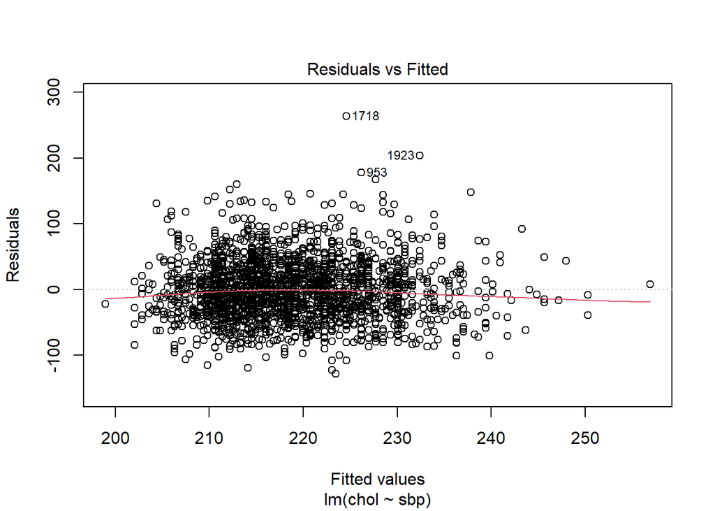

```r
#residuals and predicted values
plot(m1,1)
```

2. Explore if the residuals follow a normal distribution and if there are outliers.

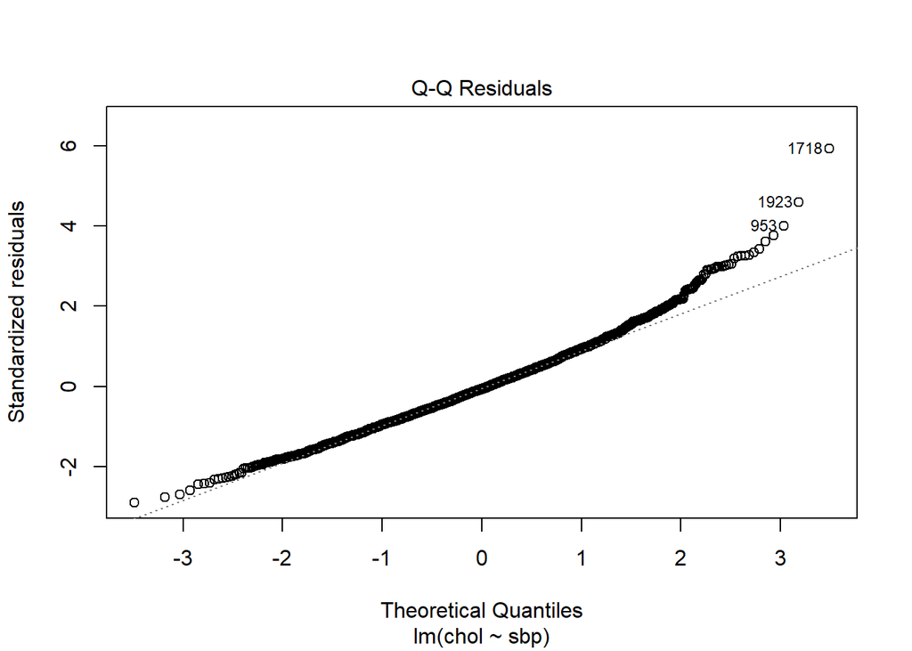

```r
#normality of residuals
plot(m1,2)
```

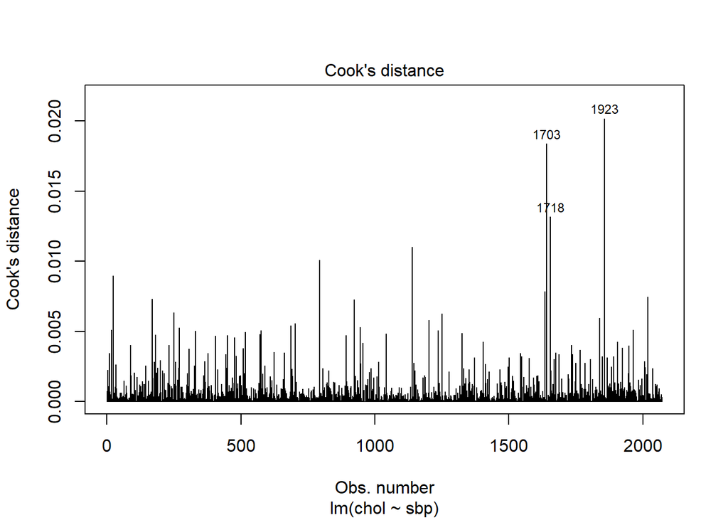

```r
#outliers
plot(m1,4)
```

**5.** Build a multiple linear regression model to explain how cholesterol values vary according to the values of systolic blood pressure and sex. Name it `m2`.

1. Is systolic blood pressure associated with cholesterol?
2. Is sex associated with cholesterol? If it is, do males have higher values of cholesterol than women?

```r
#regression model
m2 <- lm(chol ~ sbp + sex, data=regicor)
m2 |>
  tbl_regression(intercept=T)
```

| **Characteristic** | **Beta** | **95% CI** | **p-value** |
| --- | --- | --- | --- |
| (Intercept) | 168 | 156, 180 | <0.001 |
| sbp | 0.41 | 0.31, 0.50 | <0.001 |
| sex |  |  |  |
| Female | — | — |  |
| Male | -5.8 | -9.6, -1.9 | 0.003 |

Abbreviation: CI = Confidence Interval

sbp still has a statistically significant effect in cholesterol (p-value < 0.05).

For the same sex, an increase of 1 mmHg in sbp increases cholesterol in 0.41 mg/dl.

sex is associated with cholesterol: p-value < 0.05.

With the same systolic blood pressure, males have 5.8 mg/dl less cholesterol than females.

3. Which value for cholesterol does the model predict for a male individual whose sbp is 110?

```r
#prediction
newdata <- data.frame(sbp=110, sex="Male") #define new data
predict(m2,  type="response", newdata=newdata)
```

```
       1
207.1979
```

**6.** Which model (m1 or m2) is better in terms of AIC?

```r
AIC(m1); AIC(m2)
```

```
[1] 21593.27
```

```
[1] 21586.68
```

m2 is better because it has lower AIC.

**7.** Install the `mlbench` package and store `PimaIndiansDiabetes` data in an object called df.

**Note**

`PimaIndiansDiabetes` consists of several medical predictor variables and one target variable, diabetes. This dataset is originally from the National Institute of Diabetes and Digestive and Kidney Diseases of the USA and includes data on female patients at least 21 years old of Pima Indian heritage.

```r
#install.packages("mlbench")
library(mlbench)
data(PimaIndiansDiabetes)
df <- PimaIndiansDiabetes
head(df)
```

```
  pregnant glucose pressure triceps insulin mass pedigree age diabetes
1        6     148       72      35       0 33.6    0.627  50      pos
2        1      85       66      29       0 26.6    0.351  31      neg
3        8     183       64       0       0 23.3    0.672  32      pos
4        1      89       66      23      94 28.1    0.167  21      neg
5        0     137       40      35     168 43.1    2.288  33      pos
6        5     116       74       0       0 25.6    0.201  30      neg
```

**8.** Consult the help of `PimaIndiansDiabetes` to see which variables are stored in the database. Report in a table positive and negative cases of diabetes.

```r
df |>
  select(diabetes) |>
  tbl_summary(label = list(diabetes ~ "Diabetes"))
```

| **Characteristic** | **N = 768**<sup>1</sup> |
| --- | --- |
| Diabetes |  |
| neg | 500 (65%) |
| pos | 268 (35%) |

<sup>1</sup> n (%)

**9.** Let’s analyze which factors are associated with diabetes.

1. Fit a model with glucose as a predictor and diabetes as the response variable. Name it `m3`.
2. Is glucose associated with diabetes?
3. Which is the odds ratio associated to a 1-unit increase in glucose levels?

```r
m3 <- glm(diabetes ~ glucose, data=df, family=binomial)
m3 |>
  tbl_regression(exponentiate=T)
```

| **Characteristic** | **OR** | **95% CI** | **p-value** |
| --- | --- | --- | --- |
| glucose | 1.04 | 1.03, 1.05 | <0.001 |

Abbreviations: CI = Confidence Interval, OR = Odds Ratio

p-value < 0.001 -> glucose is associated with diabetes.

OR=1.04 -> for a 1-unit increase in glucose levels, the odds of having diabetes increase by 4%.

**10.** Fit an adjusted model adding BMI (`mass`) and age to the model. Name it `m4`.

1. Are all the variables associated with diabetes? Interpret the OR.

```r
m4 <- glm(diabetes ~ glucose + mass + age, data=df, family=binomial)
m4 |>
  tbl_regression(exponentiate=T)
```

| **Characteristic** | **OR** | **95% CI** | **p-value** |
| --- | --- | --- | --- |
| glucose | 1.03 | 1.03, 1.04 | <0.001 |
| mass | 1.09 | 1.06, 1.11 | <0.001 |
| age | 1.03 | 1.02, 1.05 | <0.001 |

Abbreviations: CI = Confidence Interval, OR = Odds Ratio

p-value for glucose, mass and age < 0.001 -> all variables are associated with diabetes.

Glucose: OR=1.03 -> for a 1-unit increase in glucose levels, the odds of having diabetes increase by 3%.

BMI: OR=1.09 -> for a 1-unit increase in BMI, the odds of having diabetes increase by 9%.

Age: OR=1.03 -> for a 1-year increase in age, the odds of having diabetes increase by 3%.

2. A person with higher BMI has less or more odds of having diabetes than a person with lower BMI?

BMI: OR=1.09 -> a person with higher BMI has more odds of having diabetes than a person with lower BMI

3. Which is now the OR associated with a 5-units increase in glucose?

```r
exp(5*coef(m4)["glucose"])
```

```
 glucose
1.176517
```

OR associated with 5-units increase in glucose is 1.176517.

For a 5-units increase in glucose, the odds of having diabetes increase in 17.6%.

**11.** To interpret the variable BMI in terms of categories, let’s categorize it according to the OMS categories:

- Non-obese: BMI lower than 30
- Obese: 30 or greater

```r
library(dplyr)
df <- df |>
  mutate(
    bmi_cat = case_when(
      is.na(mass) ~ NA,
      mass < 30 ~ 1,
      .default = 2
    ),
    bmi_cat = factor(bmi_cat, levels = 1:2,
              labels = c("Non-obese", "Obese"))
  )
```

**12.** Fit our last model but using categorize BMI instead of linear BMI. Name it `m5`.

1. Does being obese have a significant effect on diabetes?

```r
m5 <- glm(diabetes ~ glucose + bmi_cat + age, data=df, family=binomial)
m5 |>
  tbl_regression(exponentiate=T,
                  label = list(glucose ~"Glucose",
                                bmi_cat ~"BMI (categorized)",
                                age ~"Age"))
```

| **Characteristic** | **OR** | **95% CI** | **p-value** |
| --- | --- | --- | --- |
| Glucose | 1.03 | 1.03, 1.04 | <0.001 |
| BMI (categorized) |  |  |  |
| Non-obese | — | — |  |
| Obese | 3.80 | 2.56, 5.73 | <0.001 |
| Age | 1.03 | 1.01, 1.05 | <0.001 |

Abbreviations: CI = Confidence Interval, OR = Odds Ratio

p-value for Obese < 0.05 $\longrightarrow$ Being obese have an effect on diabetes.

2. Obese individuals have lower or higher odds of having diabetes than non-obese individuals?

For obese, OR=3.80 $\longrightarrow$ Obese individuals have higher odds of developing diabetes than non-obese individuals $\longrightarrow$ Obese individuals have almost 4 times more odds of having diabetes than non-obese individuals.

3. Do glucose and age still have an association with diabetes?

p-values for glucose and age < 0.05 $\longrightarrow$ Age and glucose have an effect on diabetes.

**13.** Given last model, plot the predicted probabilities of diabetes according to glucose and BMI.

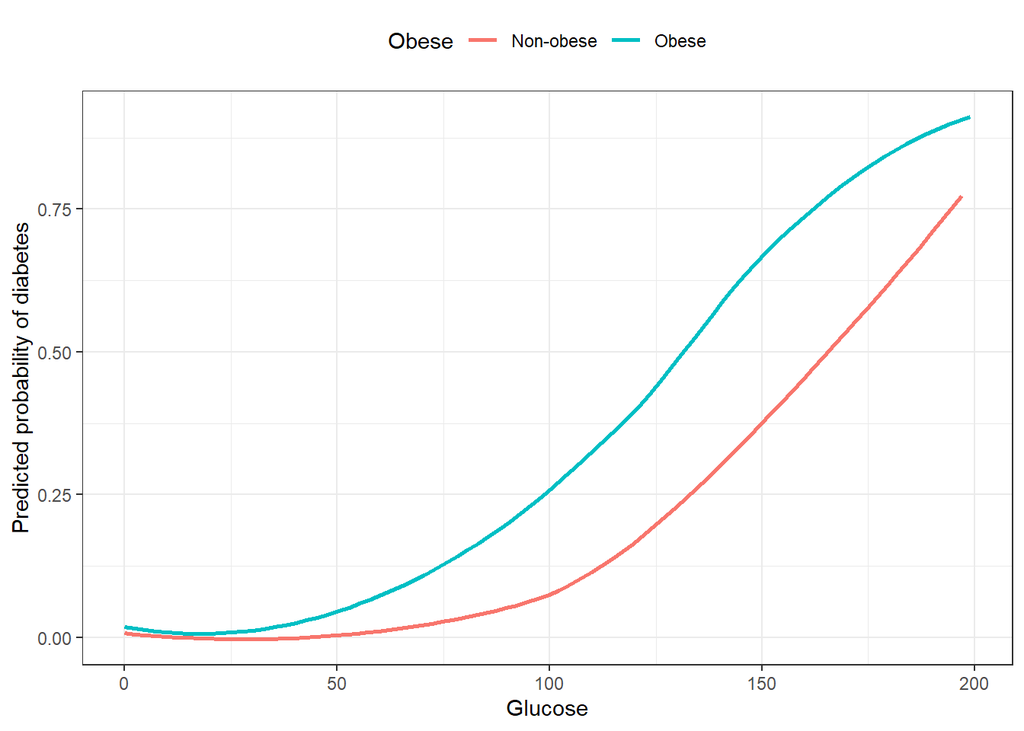

```r
df$pred <- predict(m5,  type="response", data=df)
ggplot(df, aes(x = glucose, y = pred, color = bmi_cat)) +
  geom_smooth(se = FALSE) +
  labs(x = "Glucose",
        y = "Predicted probability of diabetes",
        color = "Obese") +  # Change legend title
  theme_bw() +
  theme(legend.position = "top")  # Move legend to the top
```